# Telecom Customer Churn analysis (Ogre, July 2022)

## Telecom Customer Churn analysis Using Logistic Regression, Naive Bayes and KNN Classifiers

- Rahul Sharma (Ogre) (Author, All Rights Reserved)

#### DOMAIN: Telecom

#### DATA DESCRIPTION:

The data set includes information about:

- Customers who left within the last month – Churn (target)
- Services that each customer has signed up for – phone, multiple lines, internet, online security, online backup, device protection, tech support, and streaming TV and movies
- Customer account information – how long they've been a customer, contract, payment method, paperless billing, monthly charges, and total charges
- Demographic info about customers – gender, age range, and if they have partners and dependents

### PROJECT OBJECTIVE:

Build a model that will help to identify the potential customers who have a higher probability to churn. This helps the company to understand the patterns of customer churn and will increase the focus on strategizing customer retention.

## Data Dictionary

- CustomerID: Passenger Identity
- Gender: Whether the customer is a male or a female
- SeniorCitizen: Whether the customer is a senior citizen or not (1, 0)
- Partner: Whether the customer has a partner or not (Yes, No)
- Dependents: Whether the customer has dependents or not (Yes, No)
- Tenure: Number of months the customer has stayed with the company
- PhoneService: Whether the customer has a phone service or not (Yes, No)
- MultipleLines: Whether the customer has multiple lines or not (Yes, No, No phone service)
- InternetService: Customer’s internet service provider (DSL, Fiber optic, No)
- OnlineSecurity: Whether the customer has online security or not (Yes, No, No internet service)
- OnlineBackup: Whether the customer has online backup or not (Yes, No, No internet service)
- DeviceProtection: Whether the customer has device protection or not (Yes, No, No internet service)
- TechSupport: Whether the customer has tech support or not (Yes, No, No internet service)
- StreamingTV: Whether the customer has streaming TV or not (Yes, No, No internet service)
- StreamingMovies: Whether the customer has streaming movies or not (Yes, No, No internet service)
- Contract: The contract term of the customer (Month-to-month, One year, Two year)
- PaperlessBilling: Whether the customer has paperless billing or not (Yes, No)
- PaymentMethod: The customer’s payment method (Electronic check, Mailed check Bank transfer (automatic), Credit card (automatic))
- MonthlyCharges: The amount charged to the customer monthly
- TotalCharges: The total amount charged to the customer
- Churn: Whether the customer churned or not (Yes or No)

# 1. IMPORT AND WAREHOUSE DATA

### Importing the required libraries

```python
#-------------------------------------------------------------------------------------------------------------------------------
import pandas as pd
pd.set_option('display.max_columns', None)
pd.set_option('display.max_colwidth', None)
#-------------------------------------------------------------------------------------------------------------------------------
import numpy as np
#-------------------------------------------------------------------------------------------------------------------------------
import matplotlib.pyplot as plt
import seaborn as sns
sns.set(style='whitegrid')
sns.color_palette('dark')
%matplotlib inline
#-------------------------------------------------------------------------------------------------------------------------------
from scipy.stats import chi2_contingency, kruskal, boxcox
from statsmodels.tools.tools import add_constant
from statsmodels.stats.outliers_influence import variance_inflation_factor
#--------------------------------------------------------------------------------------------------------------------------------
from sklearn.preprocessing import LabelEncoder, MinMaxScaler
#--------------------------------------------------------------------------------------------------------------------------------
from imblearn.combine import SMOTEENN
from sklearn.model_selection import train_test_split
#--------------------------------------------------------------------------------------------------------------------------------
from sklearn.linear_model import LogisticRegression
from sklearn.neighbors import KNeighborsClassifier
from sklearn.naive_bayes import GaussianNB
from sklearn.metrics import confusion_matrix,classification_report, roc_curve, roc_auc_score, recall_score, precision_score, f1_score, accuracy_score
#--------------------------------------------------------------------------------------------------------------------------------
```

```python
!pip install imblearn
```

```python
!pip install mysql-connector-python
```

### Connecting the database created in MySQL using mysql-connector-python package

```python
import mysql.connector as sql_py
from mysql.connector import errorcode
```

```python
# try and except is important to use while making a connection with a database
# my_conf.txt file contained in the same folder as this notebook has the details to the server connection.
# we can save the details as dictionary as well. but such sensitive data should be well masked.

try:
    connection = sql_py.connect(option_files='my_conf.txt', option_groups=['connection_details'])
    if connection.is_connected():
        db_Info = connection.get_server_info()
        print("Connected to MySQL Server version ", db_Info)
        cursor = connection.cursor() #creating the cursor object for the connection
        cursor.execute("select database();")
        record = cursor.fetchone()
        print("Connected to databases:", record)
except sql_py.Error as err:
    if err.errno == errorcode.ER_ACCESS_DENIED_ERROR:
        print("Something is wrong with the user name or password")
    elif err.errno == errorcode.ER_BAD_DB_ERROR:
        print("Database does not exist")
    else:
        print(err)
```

```
Connected to MySQL Server version  8.0.29
Connected to databases: ('telecom_churn',)
```

### Import all the given datasets from MYSQL server and Explore shape and size

```python
#creating a cursor to READ t_churn_table1 with SELECT command
cursor1 = connection.cursor(raw=False)

#executing the command to fetch all the data from the table
cursor1.execute('SELECT * FROM t_churn_table1')

#saving the cursor object as matrix by selecting its elements one by one
churndata1 = [xx for xx in cursor1]

#converting the raw matrix into pandas DataFrame
churndata1 = pd.DataFrame(churndata1)

#Giving the columns of the Dataframe names
churndata1.columns = cursor1.column_names

print("Data inserted into a new pandas dataframe 'churndata1' from Table 't_churn_table1'")

#closing the cursor
cursor1.close()
```

```
Data inserted into a new pandas dataframe 'churndata1' from Table 't_churn_table1'
```

```
True
```

```python
#creating a cursor to READ t_churn_table2 with SELECT command
cursor2 = connection.cursor(raw=False)
cursor2.execute('SELECT * FROM t_churn_table2')
churndata2 = pd.DataFrame(cursor2.fetchall())
churndata2.columns = cursor2.column_names
print("Data inserted into a new pandas dataframe 'churndata2' from Table 't_churn_table2'")

#closing the cursor
cursor2.close()
```

```
Data inserted into a new pandas dataframe 'churndata2' from Table 't_churn_table2'
```

```
True
```

```python
#closing the connection. It is important to close the cursor and the connection objects.
connection.close()
print("Database connection closed")
```

```
Database connection closed
```

### Explore shape and size

```python
print(churndata1.shape)
print(churndata2.shape)
```

```
(7043, 10)
(7043, 12)
```

```python
churndata1.head()
```

|  | customerID | gender | SeniorCitizen | Partner | Dependents | tenure | PhoneService | MultipleLines | InternetService | OnlineSecurity |
| --- | --- | --- | --- | --- | --- | --- | --- | --- | --- | --- |
| 0 | 0002-ORFBO | Female | 0 | Yes | Yes | 9 | Yes | No | DSL | No |
| 1 | 0003-MKNFE | Male | 0 | No | No | 9 | Yes | Yes | DSL | No |
| 2 | 0004-TLHLJ | Male | 0 | No | No | 4 | Yes | No | Fiber optic | No |
| 3 | 0011-IGKFF | Male | 1 | Yes | No | 13 | Yes | No | Fiber optic | No |
| 4 | 0013-EXCHZ | Female | 1 | Yes | No | 3 | Yes | No | Fiber optic | No |

```python
churndata2.head()
```

|  | customerID | OnlineBackup | DeviceProtection | TechSupport | StreamingTV | StreamingMovies | Contract | PaperlessBilling | PaymentMethod | MonthlyCharges | TotalCharges | Churn |
| --- | --- | --- | --- | --- | --- | --- | --- | --- | --- | --- | --- | --- |
| 0 | 0002-ORFBO | Yes | No | Yes | Yes | No | One year | Yes | Mailed check | 65.6 | 593.30 | No |
| 1 | 0003-MKNFE | No | No | No | No | Yes | Month-to-month | No | Mailed check | 59.9 | 542.40 | No |
| 2 | 0004-TLHLJ | No | Yes | No | No | No | Month-to-month | Yes | Electronic check | 73.9 | 280.85 | Yes |
| 3 | 0011-IGKFF | Yes | Yes | No | Yes | Yes | Month-to-month | Yes | Electronic check | 98.0 | 1237.85 | Yes |
| 4 | 0013-EXCHZ | No | No | Yes | Yes | No | Month-to-month | Yes | Mailed check | 83.9 | 267.40 | Yes |

### Merging all datasets onto one and explore final shape and size.

```python
#churndata1 = pd.read_csv('https://raw.githubusercontent.com/rahultheogre/IIITD_projects/main/TelcomCustomer-Churn_1.csv')
```

```python
#churndata2 = pd.read_csv('https://raw.githubusercontent.com/rahultheogre/IIITD_projects/main/TelcomCustomer-Churn_2.csv')
```

```python
data = pd.merge(churndata1, churndata2)
```

```python
print("The shape of the data is", data.shape)
```

```
The shape of the data is (7043, 21)
```

- the data after merging operation has 21 columns and same number of instances as expected

# 2.1 DATA CLEANSING

```python
#checking basic information
data.info()
```

```
<class 'pandas.core.frame.DataFrame'>
Int64Index: 7043 entries, 0 to 7042
Data columns (total 21 columns):
 #   Column            Non-Null Count  Dtype
---  ------            --------------  -----
 0   customerID        7043 non-null   object
 1   gender            7043 non-null   object
 2   SeniorCitizen     7043 non-null   int64
 3   Partner           7043 non-null   object
 4   Dependents        7043 non-null   object
 5   tenure            7043 non-null   int64
 6   PhoneService      7043 non-null   object
 7   MultipleLines     7043 non-null   object
 8   InternetService   7043 non-null   object
 9   OnlineSecurity    7043 non-null   object
 10  OnlineBackup      7043 non-null   object
 11  DeviceProtection  7043 non-null   object
 12  TechSupport       7043 non-null   object
 13  StreamingTV       7043 non-null   object
 14  StreamingMovies   7043 non-null   object
 15  Contract          7043 non-null   object
 16  PaperlessBilling  7043 non-null   object
 17  PaymentMethod     7043 non-null   object
 18  MonthlyCharges    7043 non-null   float64
 19  TotalCharges      7043 non-null   float64
 20  Churn             7043 non-null   object
dtypes: float64(2), int64(2), object(17)
memory usage: 1.2+ MB
```

OBSERVATIONS:

- 7043 rows and 21 columns
- no null values. redundant to run isna().sum function to highlight the null values.
- Most of the features are categorical. I don't expect Logistic Regression or KNN classifier to work very well.
- Only three features are numerical
- saving them in a list; also saving categorical features in a separated list
- I will take SeniorCitizen as categorical because even it is numerical, it is discrete and has only two possible values (0,1)
- Also, I will not include 'Churn' in categoric_features because it is the prediction feature

```python
numeric_features = ['tenure','MonthlyCharges','TotalCharges']
categoric_features = ['gender', 'SeniorCitizen', 'Partner', 'Dependents', 'PhoneService', \
                      'MultipleLines', 'InternetService','OnlineSecurity', 'OnlineBackup', 'DeviceProtection',\
                      'TechSupport','StreamingTV', 'StreamingMovies', 'Contract', 'PaperlessBilling',\
                      'PaymentMethod']
```

## Checking Duplicate rows

```python
#defining a function
def ifDuplicateSamples(data):
  NoOfDuplicateRows = data.duplicated().sum()
  if NoOfDuplicateRows == 0:
    print("There are no duplicate rows")
    return
  else:
    print("There are ",NoOfDuplicateRows,"duplicate rows")

#running it on current data
ifDuplicateSamples(data)
```

```
There are no duplicate rows
```

# 2.2 EXPLORATORY DATA ANALYSIS

- I prefer to do EDA and Feature treatment together.
- I will go feature by feature, analyse them according, including UNIVARIATE and BIVARIATE analyses, and then will even take actions if needed.
- I also create an empty remove list, which I will use to remove the selected features.

```python
to_remove = []
```

## Numerical features

```python
# Function to describe a continuous feature
def num_uni_analysis(data,feature):
    variable = data[feature]
    sns.displot(x=variable,kde=True)
    plt.title(f"Distribution Plot of {feature}")
    plt.axvline(variable.mean(), color='red')
    plt.axvline(variable.median(), color='green')
    plt.show()
    print("----------------------")
    print("Skewness is: ", round(variable.skew(),4),"\n")
    print("Five point summary is: \n", variable.describe())
```

- I will first draw a correlation plot. (heatmap)
- High correlation is particularly problematic for LR (Logistic Regression) and NB (Naive Bayes)

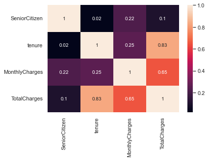

```python
sns.heatmap(round(data.corr(),2), annot = True)
plt.show()
```

- TotalCharges is highly correlated with tenure and significantly correlated with MonthlyCharges
- Let's draw the regression plotsof TotalCharges with other two after checking its distribution

## FEATURE ANALYSIS: TotalCharges

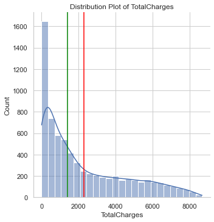

```
----------------------
Skewness is:  0.9632

Five point summary is:
 count    7043.000000
mean     2279.734304
std      2266.794470
min         0.000000
25%       398.550000
50%      1394.550000
75%      3786.600000
max      8684.800000
Name: TotalCharges, dtype: float64
```

```python
num_uni_analysis(data,'TotalCharges')
```

- mean and median are too far from each other
- the data is highly right skewed
- A skewness of 1 is almost dangerous
- It is because of many (11) 0 zero values
- In the operation of conversion of SQL tables to DataFrames through cursors, the empty strings were automatically converted into zeroes.
- Anyway, let us check the scatterplots.

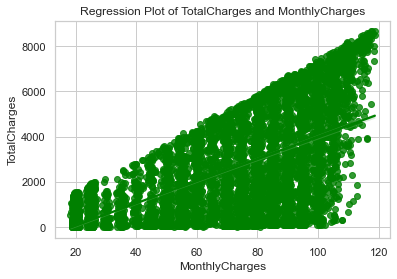

```python
sns.regplot(data=data,y='TotalCharges',x='MonthlyCharges',color='Green')
plt.title('Regression Plot of TotalCharges and MonthlyCharges')
plt.show()
```

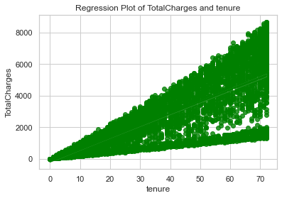

```python
sns.regplot(data=data,y='TotalCharges',x='tenure',color='Green')
plt.title('Regression Plot of TotalCharges and tenure')
plt.show()
```

- Both are linear. So we can drop 'TotalCharges'.
- Intuitively it makes a lot of sense. 'TotalCharges' is tenure* MonthlyCharges + (some_tax)
- But still, let's check VIF values

```python
def compute_vif(data, numeric_features):
    X = data[numeric_features]
    vif = pd.DataFrame()
    vif["Variable"] = X.columns
    vif["VIF"] = [variance_inflation_factor(X.values, i) for i in range(X.shape[1])]
    return vif
```

```python
compute_vif(data, numeric_features).sort_values('VIF', ascending=False)
```

|  | Variable | VIF |
| --- | --- | --- |
| 2 | TotalCharges | 8.075070 |
| 0 | tenure | 6.332328 |
| 1 | MonthlyCharges | 3.355660 |

- Variance inflation factor of 'TotalCharges' is greater than 5.
- Let's recompute VIF values after removing it.

```python
numeric_features.remove('TotalCharges')
compute_vif(data, numeric_features).sort_values('VIF', ascending=False)
```

|  | Variable | VIF |
| --- | --- | --- |
| 0 | tenure | 2.612607 |
| 1 | MonthlyCharges | 2.612607 |

- VIF of both tenure and MonthlyCharges have come down
- So, we need to remove 'TotalCharges'

```python
#adding 'TotalCharges' to remove list

to_remove.append('TotalCharges')
```

## FEATURE ANALYSIS: tenure

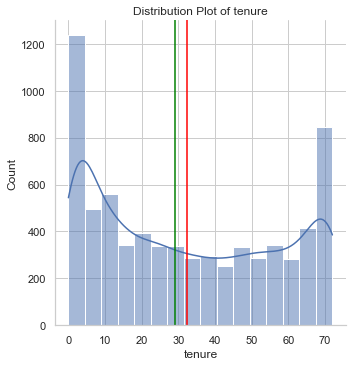

```
----------------------
Skewness is:  0.2395

Five point summary is:
 count    7043.000000
mean       32.371149
std        24.559481
min         0.000000
25%         9.000000
50%        29.000000
75%        55.000000
max        72.000000
Name: tenure, dtype: float64
```

```python
num_uni_analysis(data,'tenure')
```

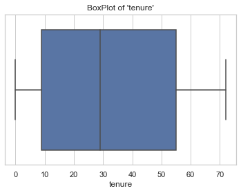

```python
sns.boxplot(data=data,x='tenure',orient='h')
plt.title("BoxPlot of 'tenure'")
plt.show()
```

- Box plot shows that the feature does not have any outliers, something I was expecting.
- Let's check how important the feature is in deciding the outcome 'Churn'.

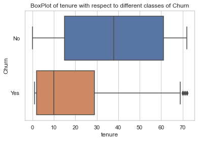

```python
sns.boxplot(data=data,x='tenure',y='Churn',orient='h')
plt.title("BoxPlot of tenure with respect to different classes of Churn")
plt.show()
```

- Clearly 'tenure' has a statistically significant role to play in deciding 'Churn'.
- Let's confirm with a Kruskal Wallis test as we presume the distribution to be non Gaussian

```python
kruskal(data['tenure'][data['Churn'] == 'Yes'],\
               data['tenure'][data['Churn'] == 'No'])
```

```
KruskalResult(statistic=948.7996915155916, pvalue=2.4191401818659714e-208)
```

- A very high value of F statistic and very low value of probability (p-value) shows we have sufficient proof to reject the null hypothesis that the median number of tenure is same for both groups of Churn- Yes and No.
- So,'tenure' is a feature of importance.

## FEATURE ANALYSIS: MonthlyCharges

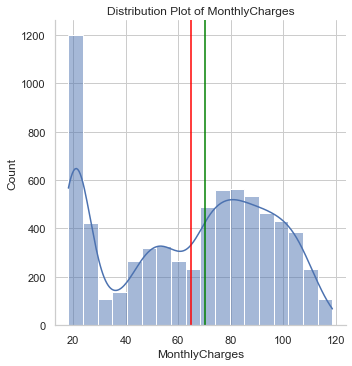

```
----------------------
Skewness is:  -0.2205

Five point summary is:
 count    7043.000000
mean       64.761692
std        30.090047
min        18.250000
25%        35.500000
50%        70.350000
75%        89.850000
max       118.750000
Name: MonthlyCharges, dtype: float64
```

```python
num_uni_analysis(data,'MonthlyCharges')
```

- A very similar story as that of tenure. But this curve is a mix of three gaussian curves.
- Let's check for outliers

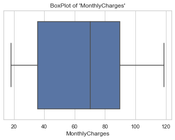

```python
sns.boxplot(data=data,x='MonthlyCharges',orient='h')
plt.title("BoxPlot of 'MonthlyCharges'")
plt.show()
```

- No outliers. We can simply do scaling without loss of sleep. But still try to bring the mean and median closer by boxcox transformation- which can be applied now, as values are non-zero positive.

```python
# creating a copy feature, in case we have to revert back
data['MC_copy'] = data['MonthlyCharges']
```

```python
data['MC_copy'],best_lambda = boxcox(data['MC_copy'])
print(best_lambda)
```

```
0.9189491915127169
```

```
The distrbution of MonthlyCharges after boxcox transformation
```

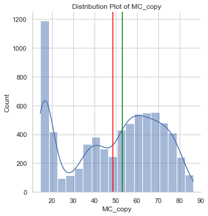

```
----------------------
Skewness is:  -0.2639

Five point summary is:
 count    7043.000000
mean       48.712991
std        21.703858
min        14.606211
25%        27.837881
50%        53.143143
75%        66.815332
max        86.650539
Name: MC_copy, dtype: float64
```

```python
print("The distrbution of MonthlyCharges after boxcox transformation")
num_uni_analysis(data,'MC_copy')
```

- The boxcox transformation was not successful as the best lambda turned out to be almost 1 (0.92)
- The skewness has increased
- Let's keep the feature as it is.

```python
data.drop(columns=['MC_copy'], inplace=True)
```

- Let's check how MonthlyCharges affect the outcome of Churn

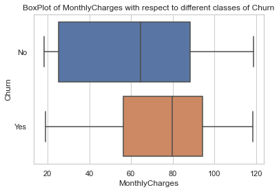

```python
sns.boxplot(data=data,x='MonthlyCharges',y='Churn',orient='h')
plt.title("BoxPlot of MonthlyCharges with respect to different classes of Churn")
plt.show()
```

- Clearly 'MonthlyCharges' has a statistically significant role to play in deciding 'Churn'.
- Let's confirm with a Kruskal Wallis test as we presume the distribution to be non Gaussian

```python
kruskal(data['MonthlyCharges'][data['Churn'] == 'Yes'],\
               data['MonthlyCharges'][data['Churn'] == 'No'])
```

```
KruskalResult(statistic=240.34263218324136, pvalue=3.3112855487838454e-54)
```

## FEATURE ANALYSIS: customerID

- This does not add any relevant information to our ML algorithm.
- It needs to be dropped.

```python
to_remove.append('customerID')
```

## Univariate and Bivariate Analysis of Categorical features

- Let's formulate some functions

```python
def pie_chart(data,feature):
    data[feature].value_counts().plot(kind='pie', autopct='%1.1f%%')
    plt.title(f"Pie Chart of {feature}")
    plt.show()
    print(data[feature].value_counts())
```

```python
def chi_2_test(data,feature1,feature2):
    ct = pd.crosstab(data[feature],data[feature2])
    c, p, dof, expected = chi2_contingency(ct)

    if p < 0.05:
        print(f"{p} is less than 0.05.")
        print(f"We reject the null hypothesis that the features are independent of each other.\n")
        print(f"So, {feature1} and {feature2}- NOT INDEPENDENT")
        if feature2 == 'Churn':
            print(f"Thus {feature1} is a feature of statistical importance.")
    else:
        print(f"{p} is greater than 0.05.")
        print(f"We fail to reject the null hypothesis that the features are independent of each other.\n")
        print(f"So {feature1} and {feature2}- INDEPENDENT")
        if feature2 == 'Churn':
            print(f"So we can drop {feature1} from our dataset.")
```

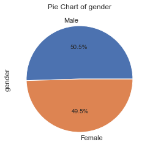

```
Male      3555
Female    3488
Name: gender, dtype: int64
-----------------------------------------------------------
```

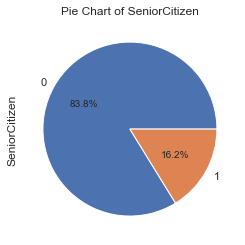

```
0    5901
1    1142
Name: SeniorCitizen, dtype: int64
-----------------------------------------------------------
```

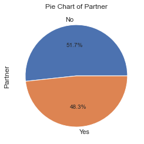

```
No     3641
Yes    3402
Name: Partner, dtype: int64
-----------------------------------------------------------
```

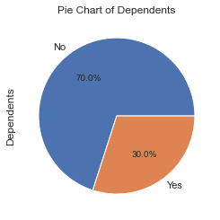

```
No     4933
Yes    2110
Name: Dependents, dtype: int64
-----------------------------------------------------------
```

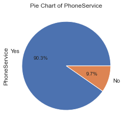

```
Yes    6361
No      682
Name: PhoneService, dtype: int64
-----------------------------------------------------------
```

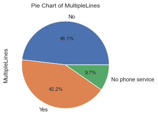

```
No                  3390
Yes                 2971
No phone service     682
Name: MultipleLines, dtype: int64
-----------------------------------------------------------
```

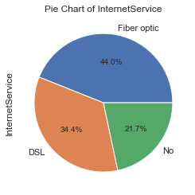

```
Fiber optic    3096
DSL            2421
No             1526
Name: InternetService, dtype: int64
-----------------------------------------------------------
```

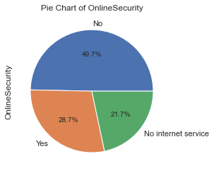

```
No                     3498
Yes                    2019
No internet service    1526
Name: OnlineSecurity, dtype: int64
-----------------------------------------------------------
```

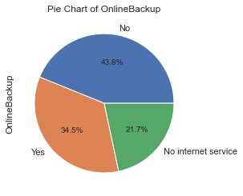

```
No                     3088
Yes                    2429
No internet service    1526
Name: OnlineBackup, dtype: int64
-----------------------------------------------------------
```

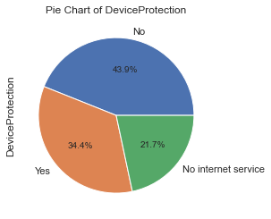

```
No                     3095
Yes                    2422
No internet service    1526
Name: DeviceProtection, dtype: int64
-----------------------------------------------------------
```

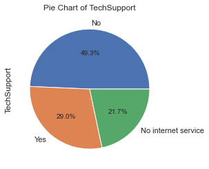

```
No                     3473
Yes                    2044
No internet service    1526
Name: TechSupport, dtype: int64
-----------------------------------------------------------
```

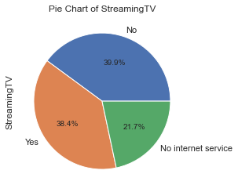

```
No                     2810
Yes                    2707
No internet service    1526
Name: StreamingTV, dtype: int64
-----------------------------------------------------------
```

[4 more figures not shown]

```
Electronic check             2365
Mailed check                 1612
Bank transfer (automatic)    1544
Credit card (automatic)      1522
Name: PaymentMethod, dtype: int64
-----------------------------------------------------------
```

```python
for feature in categoric_features:
    pie_chart(data,feature)
    print("-----------------------------------------------------------")
```

### Observations:

- Fair distribution of gender across the dataset. The company attacts both major genders of population.
- In 'SeniorCitizen', we take for granted thar 1 means that the customer is a Senior Citizen. And 0 means that the customer is not. Most of them are not Senior Citizens. Senior Citizens do not like to subscribe too much to this company.
- Almost half of the customers have partners, and half don't. Pertains to common sense.
- Almost 2/3rds of the customers don't have dependents. Pertains to common sense.
- Over 90% of the customers use PhoneService. Pertains to common sense. 9.7 percent of them might here only for Internet services. This fact is significant because it might turn out that 'PhoneService' may not be a feature of importance.
- The above data is contained in the feature 'Multiple Lines'. So we can remove 'PhoneService'. But we will confirm with a chi-2 test before going ahead.
- 21.7% of the sample population do not avail Internet Service. This figure is repeated in all those feature which correspond to InternetService being availed, i.e. OnlineSecurity, OnlineBackup, DeviceProtection, TechSupport, StreamingTV, StreamingMovies. Thus the data is consistent.
- 38.8 percent of customer use StreamingMovies service and 38.4 percent use StreamingTV. These seems to be some correlation between these two features. We will check.
- More than fifty percent of the customers prefer to have a month-to-month plan.
- More than fifty percent of the customers prefer paperless billing. Maybe the data is old. I would expect most of today's customers to prefer Paperless Billing
- There are four ways of paying bill. Almost all of them seem to see similar preference from the customers.

##### How much do the features affect 'Churn'?

```python
for feature in categoric_features:
    chi_2_test(data,feature,'Churn')
    print("-----------------------------------------------------------")
```

```
0.48657873605618596 is greater than 0.05.
We fail to reject the null hypothesis that the features are independent of each other.

So gender and Churn- INDEPENDENT
So we can drop gender from our dataset.
-----------------------------------------------------------
1.510066805092378e-36 is less than 0.05.
We reject the null hypothesis that the features are independent of each other.

So, SeniorCitizen and Churn- NOT INDEPENDENT
Thus SeniorCitizen is a feature of statistical importance.
-----------------------------------------------------------
2.1399113440759935e-36 is less than 0.05.
We reject the null hypothesis that the features are independent of each other.

So, Partner and Churn- NOT INDEPENDENT
Thus Partner is a feature of statistical importance.
-----------------------------------------------------------
4.9249216612154196e-43 is less than 0.05.
We reject the null hypothesis that the features are independent of each other.

So, Dependents and Churn- NOT INDEPENDENT
Thus Dependents is a feature of statistical importance.
-----------------------------------------------------------
0.3387825358066928 is greater than 0.05.
We fail to reject the null hypothesis that the features are independent of each other.

So PhoneService and Churn- INDEPENDENT
So we can drop PhoneService from our dataset.
-----------------------------------------------------------
0.0034643829548773 is less than 0.05.
We reject the null hypothesis that the features are independent of each other.

So, MultipleLines and Churn- NOT INDEPENDENT
Thus MultipleLines is a feature of statistical importance.
-----------------------------------------------------------
9.571788222840544e-160 is less than 0.05.
We reject the null hypothesis that the features are independent of each other.

So, InternetService and Churn- NOT INDEPENDENT
```

[output cut: 41 more lines]

```
So, Contract and Churn- NOT INDEPENDENT
Thus Contract is a feature of statistical importance.
-----------------------------------------------------------
4.073354668665985e-58 is less than 0.05.
We reject the null hypothesis that the features are independent of each other.

So, PaperlessBilling and Churn- NOT INDEPENDENT
Thus PaperlessBilling is a feature of statistical importance.
-----------------------------------------------------------
3.6823546520097993e-140 is less than 0.05.
We reject the null hypothesis that the features are independent of each other.

So, PaymentMethod and Churn- NOT INDEPENDENT
Thus PaymentMethod is a feature of statistical importance.
-----------------------------------------------------------
```

- From the above conclusions, we update our remove list

```python
to_remove.extend(['gender','PhoneService'])
```

```python
print(to_remove)
```

```
['TotalCharges', 'customerID', 'gender', 'PhoneService']
```

- Thus, we have selected four feature to remove from our dataset. We are confirmed about 'TotalCharges' and 'customerID'. Let us confirm 'gender','PhoneService'
- PhoneService- I had already argued about it. Its information is stored in MultipleLines. Now we are confirmed.
- As far as gender is concerned, let us visualize the result of chi-2 test with a crosstab.

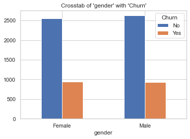

```python
ct = pd.crosstab(data['gender'],data['Churn'])
ct.plot(kind="bar", stacked=False, rot=0)
plt.title("Crosstab of 'gender' with 'Churn'")
plt.show()
```

- No difference in means of counts of Churn with respect to both genders- Male and Female.
- So, we will go ahead with its removal.
- Let us now get the values of chi-2 tests of rest of categorical features.

```python
categoric_features = [x for x in categoric_features if x not in to_remove]
```

```python
for i in range(len(categoric_features)-1):
    chi_2_test(data,categoric_features[i],categoric_features[i+1])
    print("-----------------------------------------------------------")
```

```
3.3445533875870503e-40 is less than 0.05.
We reject the null hypothesis that the features are independent of each other.

So, SeniorCitizen and Partner- NOT INDEPENDENT
-----------------------------------------------------------
1.7935563214873815e-34 is less than 0.05.
We reject the null hypothesis that the features are independent of each other.

So, Partner and Dependents- NOT INDEPENDENT
-----------------------------------------------------------
1.1367151062832025e-81 is less than 0.05.
We reject the null hypothesis that the features are independent of each other.

So, Dependents and MultipleLines- NOT INDEPENDENT
-----------------------------------------------------------
3.0319707718157943e-295 is less than 0.05.
We reject the null hypothesis that the features are independent of each other.

So, MultipleLines and InternetService- NOT INDEPENDENT
-----------------------------------------------------------
7.427176940680162e-280 is less than 0.05.
We reject the null hypothesis that the features are independent of each other.

So, InternetService and OnlineSecurity- NOT INDEPENDENT
-----------------------------------------------------------
1.1619696858579123e-239 is less than 0.05.
We reject the null hypothesis that the features are independent of each other.

So, OnlineSecurity and OnlineBackup- NOT INDEPENDENT
-----------------------------------------------------------
1.7597723605000128e-247 is less than 0.05.
We reject the null hypothesis that the features are independent of each other.

So, OnlineBackup and DeviceProtection- NOT INDEPENDENT
-----------------------------------------------------------
1.864283565249669e-283 is less than 0.05.
We reject the null hypothesis that the features are independent of each other.

So, DeviceProtection and TechSupport- NOT INDEPENDENT
-----------------------------------------------------------
```

[output cut: 10 more lines]

```
4.067638353787387e-213 is less than 0.05.
We reject the null hypothesis that the features are independent of each other.

So, StreamingMovies and Contract- NOT INDEPENDENT
-----------------------------------------------------------
4.115239070710319e-94 is less than 0.05.
We reject the null hypothesis that the features are independent of each other.

So, Contract and PaperlessBilling- NOT INDEPENDENT
-----------------------------------------------------------
0.0 is less than 0.05.
We reject the null hypothesis that the features are independent of each other.

So, PaperlessBilling and PaymentMethod- NOT INDEPENDENT
-----------------------------------------------------------
```

- Above observations clearly conclude that none of the two features are independent of each other.
- But, can we do something about it?
- Yes, we can perform a PCA and use eigenvectors as new features to feed into the ML algorithms.
- But we don't do that now.
- Let us use dataset we have, and feed it into the ML algorithms and observe their relative performance.

# 3. DATA PREPARATION FOR MODEL BUILDING

```python
#create a copy of the data
data1 = data
```

#### REMOVING FEATURES THAT PLAY LITTLE IMPORTANCE IN DECIDING CHURN

```python
data1.drop(columns = to_remove, inplace=True)
```

#### ENCODING THE CATEGORICAL DATA

- I will LabelEncode all the categoric features, because increased dimensionality of the dataset affects LR nd KNN.

```python
# SeniorCitizen is already encoded
categoric_features.remove('SeniorCitizen')

#adding Churn to the list
categoric_features.append('Churn')
```

```python
le = LabelEncoder() #label encoder object

def label_encode(data,ToBeLabelEncoded):
  for feature in ToBeLabelEncoded:
    data[feature] = le.fit_transform(data[feature])

label_encode(data1,categoric_features)
```

### SCALING

- I will use MinMaxScaler because most of the features are categorical.
- Standard Scaling is more suited to continuous features in my experience

```python
scaler = MinMaxScaler(feature_range =(0, 1))
scaler.fit(data1)
data2 = pd.DataFrame(scaler.transform(data1))
data2.columns = data1.columns
data2.head()
```

|  | SeniorCitizen | Partner | Dependents | tenure | MultipleLines | InternetService | OnlineSecurity | OnlineBackup | DeviceProtection | TechSupport | StreamingTV | StreamingMovies | Contract | PaperlessBilling | PaymentMethod | MonthlyCharges | Churn |
| --- | --- | --- | --- | --- | --- | --- | --- | --- | --- | --- | --- | --- | --- | --- | --- | --- | --- |
| 0 | 0.0 | 1.0 | 1.0 | 0.125000 | 0.0 | 0.0 | 0.0 | 1.0 | 0.0 | 1.0 | 1.0 | 0.0 | 0.5 | 1.0 | 1.000000 | 0.471144 | 0.0 |
| 1 | 0.0 | 0.0 | 0.0 | 0.125000 | 1.0 | 0.0 | 0.0 | 0.0 | 0.0 | 0.0 | 0.0 | 1.0 | 0.0 | 0.0 | 1.000000 | 0.414428 | 0.0 |
| 2 | 0.0 | 0.0 | 0.0 | 0.055556 | 0.0 | 0.5 | 0.0 | 0.0 | 1.0 | 0.0 | 0.0 | 0.0 | 0.0 | 1.0 | 0.666667 | 0.553731 | 1.0 |
| 3 | 1.0 | 1.0 | 0.0 | 0.180556 | 0.0 | 0.5 | 0.0 | 1.0 | 1.0 | 0.0 | 1.0 | 1.0 | 0.0 | 1.0 | 0.666667 | 0.793532 | 1.0 |
| 4 | 1.0 | 1.0 | 0.0 | 0.041667 | 0.0 | 0.5 | 0.0 | 0.0 | 0.0 | 1.0 | 1.0 | 0.0 | 0.0 | 1.0 | 1.000000 | 0.653234 | 1.0 |

# TRAIN-TEST SPLIT & RESAMPLING DATA

```python
# Getting the Predictors matrix and Prediction Set

X = data2.drop('Churn',axis=1)
Y = data2['Churn']
```

#### Analyzing Prediction Feature

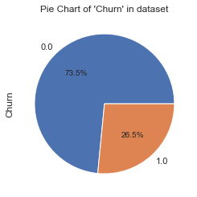

```python
Y.value_counts().plot(kind='pie', autopct='%1.1f%%')
plt.title("Pie Chart of 'Churn' in dataset")
plt.show()
```

```python
# Appling SMOTE EN resampling over the dataset

X, Y = SMOTEENN().fit_resample(X, Y)
print("After SMOTE-ENN resampling, the size of the prediction and predictor set is:")
print(X.shape,Y.shape)
```

```
After SMOTE-ENN resampling, the size of the prediction and predictor set is:
(6249, 16) (6249,)
```

- Checking the distribution of Y (prediction) post resampling

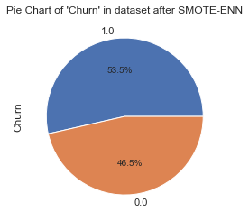

```python
Y.value_counts().plot(kind='pie', autopct='%1.1f%%')
plt.title("Pie Chart of 'Churn' in dataset after SMOTE-ENN")
plt.show()
```

- Class distribution is much better than before. We can go ahead with modeling now.
- Splitting the data into training and testing set in 70:30 ratio

```python
X_train, X_test, Y_train, Y_test = train_test_split(X,Y,test_size=0.30,random_state=41)

print(X_train.shape,Y_train.shape)
print(X_test.shape,Y_test.shape)
```

```
(4374, 16) (4374,)
(1875, 16) (1875,)
```

# 4. MODEL TRAINING AND TESTING

```python
# First defining a function which evalutes a Classfier model

def EvaluateClassifier(Y_test,y_hat):
  print("----------------------------------------------------------------------\n")
  cf_matrix = confusion_matrix(Y_test, y_hat)
  names = ['TN','FP','FN','TP']
  counts = ['{0:0.0f}'.format(value) for value in cf_matrix.flatten()]
  percentages = ['{0:.2%}'.format(value) for value in cf_matrix.flatten()/np.sum(cf_matrix)]
  labels = [f'{v1}\n{v2}\n{v3}' for v1, v2, v3 in zip(names,counts,percentages)]
  labels = np.asarray(labels).reshape(2,2)
  sns.heatmap(cf_matrix, annot=labels, fmt='', cmap='Wistia')
  plt.title("Confusion Matrix")
  plt.show()


  print("\n----------------------------------------------------------------------\n")
  print("Classification Report")
  print(classification_report(Y_test,y_hat))

  print("\n----------------------------------------------------------------------\n")
  fpr, tpr, thresholds = roc_curve(Y_test, y_hat)
  plt.plot(fpr, tpr)
  # set limits for x and y axes
  plt.xlim([0.0, 1.0])
  plt.ylim([0.0, 1.0])
  # plot the straight line showing worst prediction for the model
  plt.plot([0, 1], [0, 1],'r--')

  plt.title('AUC-ROC curve')
  plt.xlabel('FPR (1-Specificity)')
  plt.ylabel('TPR (Sensitivity)')
  plt.text(x = 0.02, y = 0.9, s = ('AUC Score:', round(roc_auc_score(Y_test, y_hat),3)))
  plt.show()
  print("\n----------------------------------------------------------------------")
```

```python
# DEFINING A FUNCTION WHICH DISPLAYS TRAIN AND TEST ACCURACY
def train_test_accuracy(classifier):
    y_pred_train = classifier.predict(X_train)
    y_pred_test = classifier.predict(X_test)
    train_accuracy = accuracy_score(Y_train,y_pred_train)
    test_accuracy = accuracy_score(Y_test,y_pred_test)
    print(f"For {classifier}:")
    print(f"Train accuracy is {train_accuracy}, and\nTest accuracy is {test_accuracy}")
    return
```

## USING NAIVE BAYES Classifier

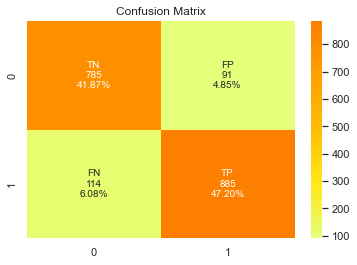

```
----------------------------------------------------------------------

Classification Report
              precision    recall  f1-score   support

         0.0       0.87      0.90      0.88       876
         1.0       0.91      0.89      0.90       999

    accuracy                           0.89      1875
   macro avg       0.89      0.89      0.89      1875
weighted avg       0.89      0.89      0.89      1875


----------------------------------------------------------------------
```

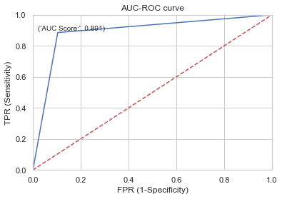

```python
# Fitting the model into train data, calculating predicted y's of test data,
# And evaluating the model

NaiveBayes = GaussianNB()
NaiveBayes.fit(X_train, Y_train)
EvaluateClassifier(Y_test,NaiveBayes.predict(X_test))
```

```python
train_test_accuracy(NaiveBayes)
```

```
For GaussianNB():
Train accuracy is 0.8888888888888888, and
Test accuracy is 0.8906666666666667
```

## LOGISTIC REGRESSION

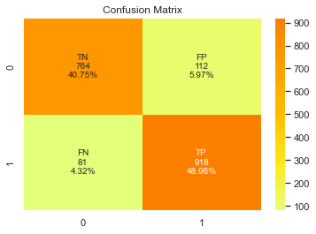

```
----------------------------------------------------------------------

Classification Report
              precision    recall  f1-score   support

         0.0       0.90      0.87      0.89       876
         1.0       0.89      0.92      0.90       999

    accuracy                           0.90      1875
   macro avg       0.90      0.90      0.90      1875
weighted avg       0.90      0.90      0.90      1875


----------------------------------------------------------------------
```

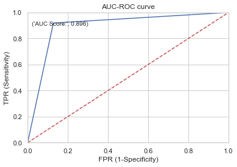

```python
# Fitting the model into train data, calculating predicted y's of test data,
# And evaluating the model

LogReg = LogisticRegression()
LogReg.fit(X_train, Y_train)
y_hat = LogReg.predict(X_test)
EvaluateClassifier(Y_test,y_hat)
```

```python
train_test_accuracy(LogReg)
```

```
For LogisticRegression():
Train accuracy is 0.9007773205304069, and
Test accuracy is 0.8970666666666667
```

## KNN Clasifier

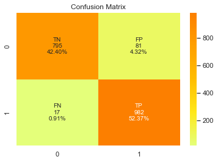

```
----------------------------------------------------------------------

Classification Report
              precision    recall  f1-score   support

         0.0       0.98      0.91      0.94       876
         1.0       0.92      0.98      0.95       999

    accuracy                           0.95      1875
   macro avg       0.95      0.95      0.95      1875
weighted avg       0.95      0.95      0.95      1875


----------------------------------------------------------------------
```

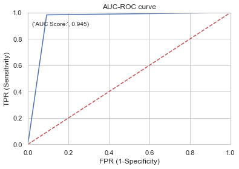

```python
# Fitting the model into train data, calculating predicted y's of test data,
# And evaluating the model

KNN = KNeighborsClassifier()
KNN.fit(X_train, Y_train)
y_hat = KNN.predict(X_test)
EvaluateClassifier(Y_test,y_hat)
```

- Even with the default K=5, the model is working well and is the best of the three we have chosen to analyze.
- It is simply because the algorithm is instance based and non-parametric.
- In KNN, the choice of k is very critical. A small value of k means that noise will have a higher influence on the result. A large value makes it computationally expensive and is contradictory to the basic idea behind KNN, that close points might have similar densities or classes.
- We need to create an 'Error_Rate vs K' plot. And choose the K with minimum Error Rate.

```python
def KvsErrorRatePLOT():
  error_rate = []
  for i in range(1,30):
    knn = KNeighborsClassifier(n_neighbors=i)
    knn.fit(X_train,Y_train)
    yi_cap = knn.predict(X_test)
    error_rate.append(np.mean(yi_cap != Y_test))

  plt.figure(figsize=(10,6))
  plt.plot(range(1,30),error_rate,color='Green', linestyle='dashed',\
             marker='X', markerfacecolor='Red', markersize=7)
  plt.title('Error Rate vs. K')
  plt.xlabel('K value')
  plt.ylabel('Error Rate')
  plt.show()
```

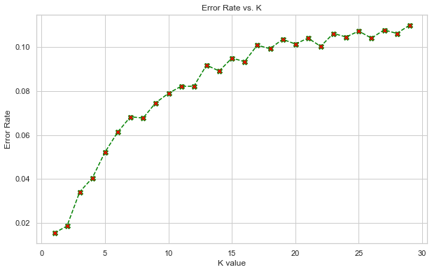

```python
KvsErrorRatePLOT()
```

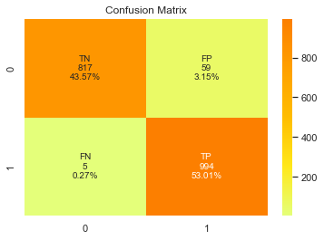

```
----------------------------------------------------------------------

Classification Report
              precision    recall  f1-score   support

         0.0       0.99      0.93      0.96       876
         1.0       0.94      0.99      0.97       999

    accuracy                           0.97      1875
   macro avg       0.97      0.96      0.97      1875
weighted avg       0.97      0.97      0.97      1875


----------------------------------------------------------------------
```

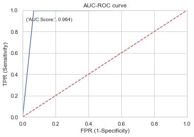

```python
KNN = KNeighborsClassifier(n_neighbors=3)
KNN.fit(X_train, Y_train)
y_hat = KNN.predict(X_test)
EvaluateClassifier(Y_test,y_hat)
```

```python
train_test_accuracy(KNN)
```

```
For KNeighborsClassifier(n_neighbors=3):
Train accuracy is 0.9887974394147233, and
Test accuracy is 0.9658666666666667
```

# 5. Conclusion and improvisation